# Plot Tests

John Yuill

December 11, 2016

## PURPOSE

- compare major graphing options
- Load required libraries

```r
library(plotly)
library(ggplot2)
library(ggvis)
library(googleVis)
```

## EXAMPLES

### 1. ggplot2

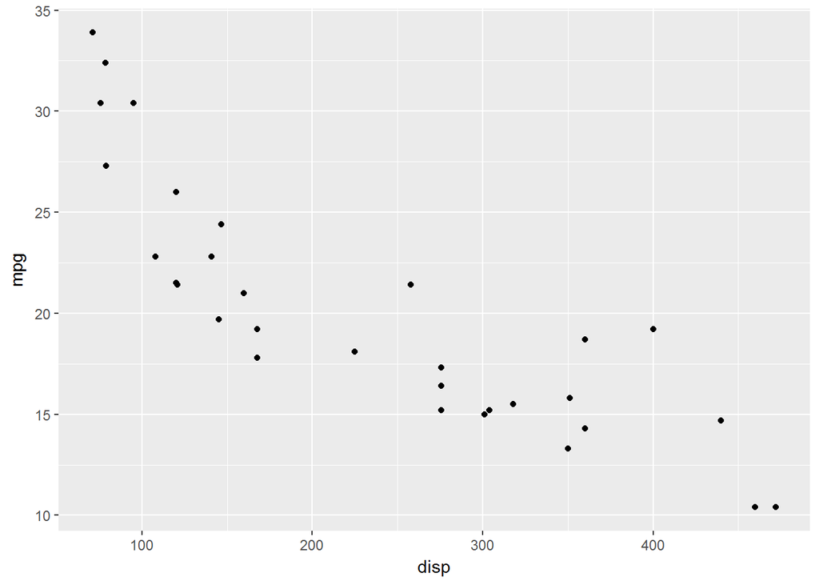

#### Pros

- super-control over plot features and format
- uses grammar of graphics
- lots of usage and support
- good skill level already attained, with lots of home-made examples

#### Cons

- no further ‘official’ development - basically abandoned in favour of ggvis
- no built-in interactivity
- can be cumbersome code
- can’t easily download

#### Use

- static charts, including R Markdown HTML files
- maybe with Shiny, but probably choose alternatives below

### 2. ggvis

#### Pros

- designed for more interactivity than ggplot2 (although require shiny)
- defaults to cleaner style than ggplot2
- takes advantage of pipe (%>%) and integrates with dplyr
- easy export/download

#### Cons

- interactivity requires Shiny

#### Use

- in shiny apps

### 3. Plotly

[interactive chart not shown]

#### Pros

- full-on library of interactive charts
- can embed charts with some interactivity in R Markdown HTML files

#### Cons

- interactivity is limited to zooming, hover labels (which is cool but not sufficient)
- for shiny, requires library on shiny server - compatible version
- recent update (v4.0) not backwards compatible, breaking older charts

#### Use

- embed in R Markdown HTML for limited interactivity
- possibly with shiny

## 4. Google Viz

#### Pros

- Well-developed Google chart library

#### Cons

- displays in browser, not R plot window
- doesn’t directly integrate with R Markdown HTML docs

## Conclusion

- ggplot for exploration within R and for static charts in R markdown
- get up to speed with more ggvis, as it is likely future of R graphics
- get up to speed on shiny + ggvis
- keep plotly in mind for situations that may arise